# Anomalías térmicas en Costa Rica

Detecciones del sensor MODIS (MODIS_SP de NASA FIRMS) y área quemada (MCD64A1)

Autor/a

Organización Incendios Forestales

Fecha de publicación

12 de septiembre de 2026

## Introducción

Este reporte presenta las anomalías térmicas (detecciones de fuego activo) registradas por el sensor MODIS en el territorio continental de **Costa Rica**. Los datos provienen del producto **MODIS_SP** (procesamiento estándar) del sistema [FIRMS](https://firms.modaps.eosdis.nasa.gov/) de la NASA, y el límite nacional se construye como la unión de las siete provincias de la cartografía oficial 1:5000 del Instituto Geográfico Nacional, servida por el [SNIT](https://www.snitcr.go.cr/).

El ámbito es **continental**: la Isla del Coco queda fuera del análisis. Su actividad de fuego es prácticamente nula y de incluirla el rectángulo de descarga se extendería sobre cientos de kilómetros de océano, donde los sensores registran sobre todo barcos como anomalías térmicas nocturnas.

Existen tres reportes análogos, con los mismos productos y metodología, basados en el sensor VIIRS (375 m): uno en la plataforma Suomi-NPP (desde 2012), otro en NOAA-20 (desde 2018) y otro en NOAA-21 (desde 2024). Las series de cada plataforma se publican por separado y no deben sumarse: VIIRS detecta muchos más fuegos que MODIS sobre el mismo territorio, y dos satélites observan más veces que uno, así que unirlas produciría saltos artificiales —en 2012 y en 2018— que reflejarían el instrumental disponible y no el régimen de fuego.

El período analizado va del **04/01/2001** al **22/08/2026**, con un total de **29 520** detecciones dentro del país. El límite nacional está delimitado a escala 1:5000, una precisión muy superior a la de los píxeles MODIS (~1 km), así que el recorte no introduce error apreciable por la geometría del límite; las detecciones descartadas por él son sobre todo marinas (barcos) o de los países vecinos.

Una advertencia de interpretación que a escala nacional pesa más que en un área protegida: una **anomalía térmica no es necesariamente un incendio forestal**. El sensor registra cualquier fuente de calor suficientemente intensa, y en Costa Rica eso incluye las quemas agrícolas (caña de azúcar, pastos) y ocasionalmente fuentes industriales, además de los incendios de vegetación.

## Mapa animado

Detecciones mensuales de anomalías térmicas; el color indica la potencia radiativa del fuego (FRP).

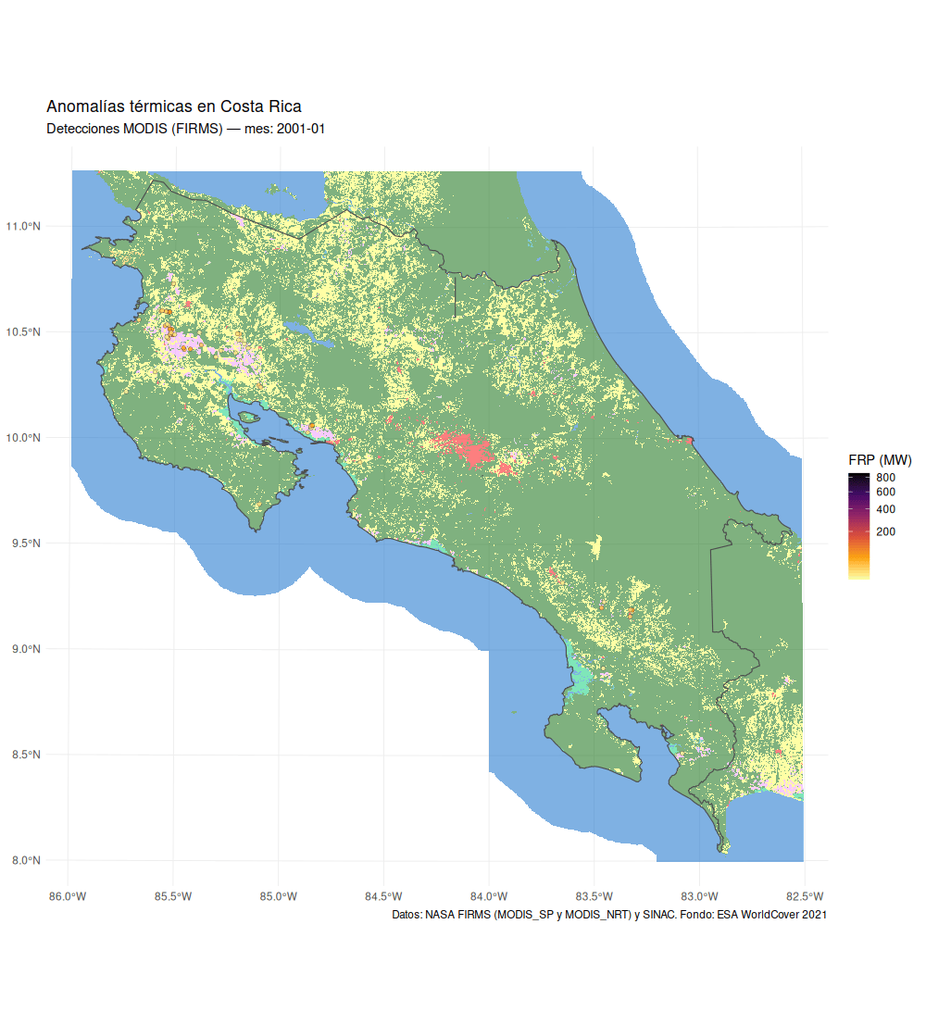

## Video resumen

Resumen mensual 2001–2026 en formato de video: detecciones de fuego activo (MODIS) con su estela de los meses recientes y píxeles de área quemada (MCD64A1), sobre el relieve del país teñido por la cobertura de la tierra (WorldCover 2021). Los contadores muestran el acumulado desde 2001 y, debajo, el mes en curso con sus valores, cada serie por separado: son magnitudes complementarias y no sumables.

[video not shown]

El cartel estático resume las dos series mensuales del video: los acumulados arriba y, en paneles separados —son magnitudes complementarias y no sumables—, las hectáreas quemadas y las detecciones por mes, con el mes máximo de cada serie rotulado.

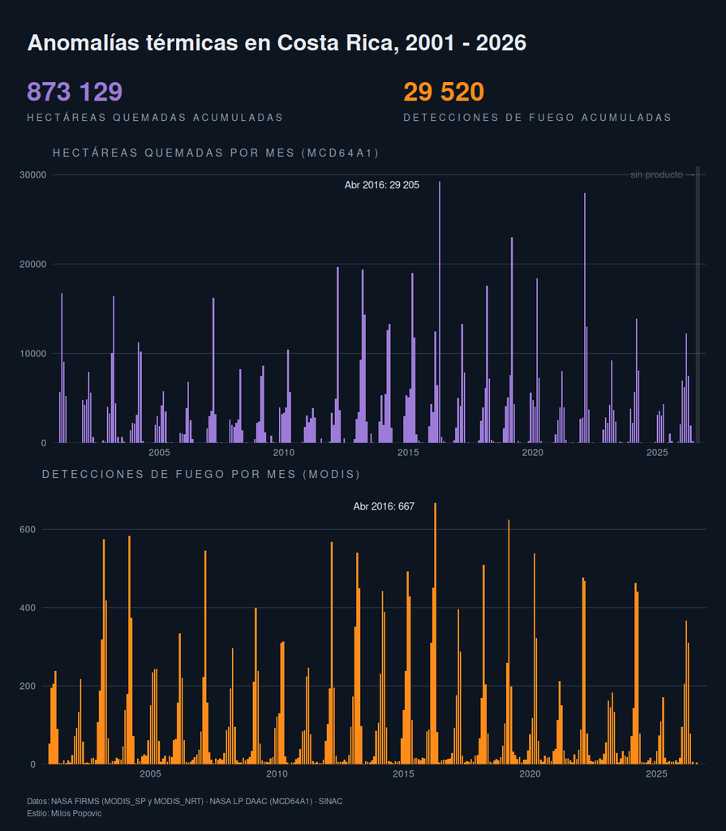

## Mapa interactivo

A escala nacional el registro completo suma demasiadas detecciones para mostrar cada una con su ficha, así que el mapa las divide en dos capas:

- **Los últimos 24 meses** —la ventana de monitoreo— con el deslizador temporal y una ficha por detección (pulse un punto para ver sus atributos, incluida la cobertura de la tierra dominante en su footprint).
- **El registro completo** como una capa de puntos ligera (WebGL), sin fichas, apagada al inicio: actívela desde el control de capas para ver el patrón espacial acumulado de todo el período.

El botón ⛶ de la esquina superior izquierda abre el mapa en pantalla completa. Desde el control de capas pueden activarse además el área quemada reciente (píxeles de MCD64A1, con su fecha de quema en el popup, filtrados por el deslizador igual que las detecciones), la cobertura ([ESA WorldCover 2021](https://esa-worldcover.org/)), las áreas de conservación del SINAC y la temporada de fuego consolidada por celda (ver la sección Temporada de fuego).

[interactive chart not shown]

## Área quemada (MCD64A1)

Las detecciones de fuego activo indican dónde había fuego al paso del satélite; el producto complementario **MCD64A1** (MODIS, colección 6.1) mapea el **área quemada**: para cada píxel de 500 m (~21,5 ha) registra el día en que la superficie quedó marcada por el fuego, a partir del cambio persistente de reflectancia. Aunque FIRMS lista este producto (`BA_MODIS`) y lo dibuja en su visor, su API no lo entrega como datos, por lo que el pipeline lo descarga del archivo original de la NASA (LP DAAC). Costa Rica cruza dos teselas de la rejilla sinusoidal del producto (h09v07 y h09v08), de modo que cada mes requiere dos gránulos. El producto se publica con uno o dos meses de rezago: su serie puede terminar antes que la de detecciones.

Las estadísticas de las secciones siguientes presentan ambas magnitudes lado a lado. **Limitación**: la unidad mínima de MCD64A1 es el píxel de 500 m — quemas menores pueden no detectarse y la superficie reportada es la del píxel completo, no la de la cicatriz interna—, por lo que las hectáreas son una estimación gruesa, útil para comparar años y estaciones entre sí.

## Estadísticas

### Serie temporal mensual

Detecciones de fuego activo (arriba) y hectáreas quemadas (abajo), con el eje temporal compartido: acerque con la rueda o arrastre una región para explorar un período; pase el cursor sobre una barra para ver el detalle del mes.

Las dos series son complementarias y **no sumables**: las detecciones cuentan eventos de fuego activo en el momento del sobrevuelo —un mismo incendio genera muchas detecciones a lo largo de días—, mientras que el área quemada mide la superficie que quedó marcada, contada una sola vez. Un mes con muchas detecciones y pocas hectáreas sugiere fuegos recurrentes en poca superficie (o fuegos menores que el píxel de 500 m); el caso inverso, una quema extensa y rápida entre sobrevuelos.

[interactive chart not shown]

### Climatología mensual (estacionalidad)

Promedios por mes calendario de ambas magnitudes. La concentración en la estación seca (enero–abril) es el rasgo dominante del régimen de fuego costarricense. El promedio de hectáreas de los meses más recientes puede estar levemente subestimado por el rezago de publicación de MCD64A1.

[interactive chart not shown]

### Resumen anual

Los años sin detecciones muestran el FRP en blanco (no hubo detecciones que promediar); 0 hectáreas significa que MCD64A1 no marcó píxeles quemados ese año.

| Año | Detecciones | Hectáreas quemadas | FRP promedio (MW) | FRP máximo (MW) |
| --- | --- | --- | --- | --- |
| 2001 | 836 | 41582 | 25 | 321.4 |
| 2002 | 733 | 27793 | 23.6 | 396.2 |
| 2003 | 1671 | 39317 | 25.3 | 467.3 |
| 2004 | 1499 | 32026 | 32.4 | 798.6 |
| 2005 | 1082 | 17531 | 24.4 | 415.6 |
| 2006 | 947 | 16248 | 22.6 | 350.7 |
| 2007 | 1134 | 30808 | 21.1 | 177 |
| 2008 | 848 | 18964 | 26.3 | 859.8 |
| 2009 | 1091 | 27921 | 24.6 | 315.2 |
| 2010 | 980 | 28306 | 23.4 | 379.3 |

[output cut: 16 more lines]

## Temporada de fuego

Los promedios mensuales describen la temporada típica; esta sección mide la temporada de **cada año**. La unidad es el **año de fuego**, del 1 de setiembre al 31 de agosto, nombrado por el año en que termina: se corta en el mínimo de actividad (entre junio y octubre ocurre menos del 2 % de las detecciones) para que ninguna temporada quede partida, y contiene enteras tanto la época seca del Pacífico que describe el IMN (diciembre a abril) como la temporada de incendios que define el SINAC (enero a mayo, «pudiéndose adelantar o postergar dependiendo del comportamiento climático»). El año de fuego 2024 contiene, así, la temporada 2024 del SINAC.

Para cada año se calcula el **inicio** (`INI`) y el **fin** (`FIN`) de la temporada observada como los primeros días en que la suma acumulada de detecciones alcanza el 10 % y el 90 % del total anual, y la **longitud** (`LON`) como los días entre ambos. Al depender de fracciones del total y no del conteo, la longitud es insensible a los cambios de detectabilidad de la serie MODIS (los años 2001 y 2002 con solo Terra; la deriva de las horas de paso desde 2020). Solo cuentan las detecciones de **vegetación** (columna `type` de FIRMS igual a 0 o ausente); volcanes y fuentes estáticas se apartan porque producen «temporadas» todo el año. Las definiciones completas y su sustento están en el [README](https://github.com/incendios-forestales/anomalias-termicas-costarica#año-de-fuego-e-índices-anuales).

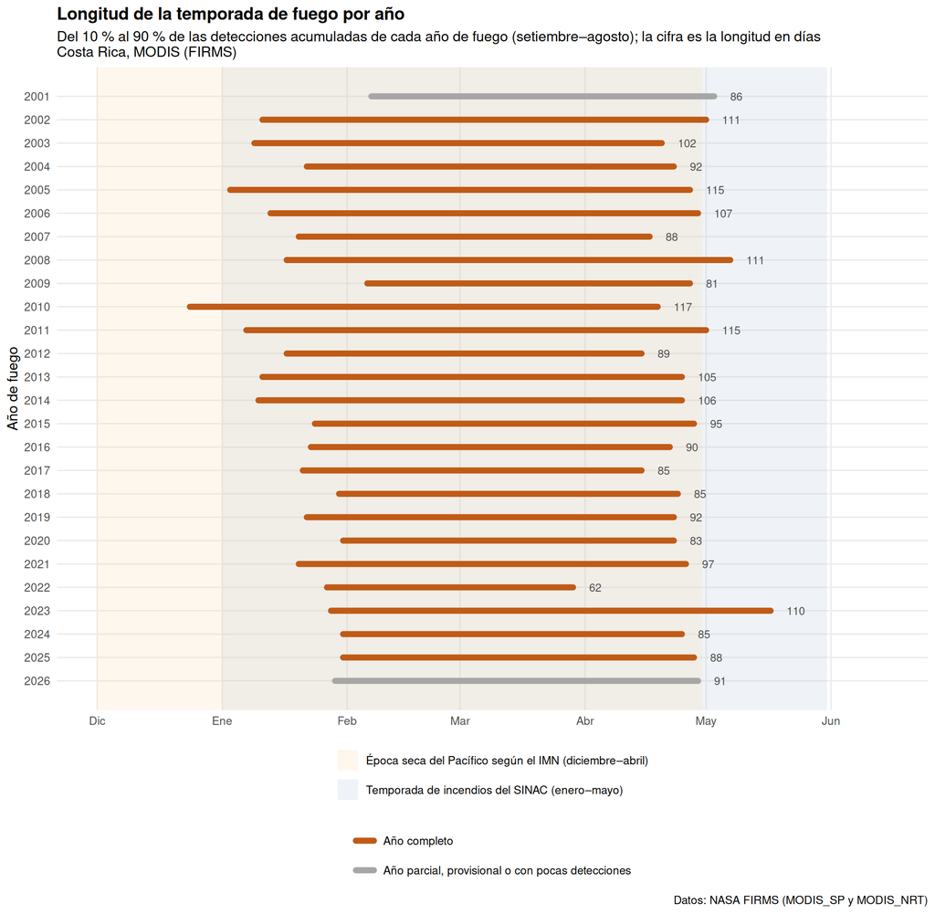

En los **24 años completos** (2002 a 2025, sin reservas de lectura) la temporada dura en promedio **96 días**, entre los 62 de 2022 y los 117 de 2010. La mediana del inicio cae el 20 de enero y la del fin el 25 de abril. El inicio más temprano fue el 24 de diciembre de 2009 y el más tardío el 6 de febrero de 2009; el fin más temprano, el 29 de marzo de 2022, y el más tardío, el 17 de mayo de 2023.

Los años en gris tienen alguna reserva: el año de fuego 2001 es **parcial** (la serie empieza en enero de 2001 y le faltan setiembre a diciembre de 2000), igual que el año de fuego recién iniciado; un año es **provisional** cuando parte de sus días proviene del procesamiento en tiempo casi real, que la NASA refina al reprocesarlo a estándar (hoy, los meses posteriores a 30 de junio de 2026); y un año con menos de 300 detecciones tiene fechas que dependen de un puñado de días.

| Año de fuego | Detecciones | Inicio (10 %) | Fin (90 %) | Longitud (días) | Nota |
| --- | --- | --- | --- | --- | --- |
| 2001 | 775 | 7 de febrero | 3 de mayo | 86 | año parcial |
| 2002 | 599 | 11 de enero | 1 de mayo | 111 |  |
| 2003 | 1657 | 9 de enero | 20 de abril | 102 |  |
| 2004 | 1399 | 22 de enero | 22 de abril | 92 |  |
| 2005 | 1008 | 3 de enero | 27 de abril | 115 |  |
| 2006 | 884 | 13 de enero | 29 de abril | 107 |  |
| 2007 | 1074 | 20 de enero | 17 de abril | 88 |  |
| 2008 | 782 | 17 de enero | 6 de mayo | 111 |  |
| 2009 | 955 | 6 de febrero | 27 de abril | 81 |  |
| 2010 | 989 | 24 de diciembre | 19 de abril | 117 |  |

[output cut: 17 more lines]

La tabla completa, con las fechas y las marcas por año, está disponible como CSV.

### Temporada consolidada por celda

La versión espacial del índice responde a dónde empieza y termina la temporada. Es un producto **consolidado**: para cada celda de 0,1° (~11 km) se juntan las detecciones de vegetación de los años de fuego completos (2002–2025) y se calculan `INI`, `FIN` y `LON` sobre esa distribución de fechas. Es la temporada *climatológica* de la celda, y no el promedio de sus temporadas anuales: al incluir la variabilidad entre años, es más ancha. No hay mapas por año: con MODIS, casi ninguna celda reúne en un solo año las detecciones necesarias para fechar su temporada; la dimensión interanual espacial corresponde a las áreas de conservación. Las celdas con menos de 30 detecciones acumuladas quedan sin índices y se dibujan en gris.

La definición supone una sola temporada por celda. En las llanuras del norte y la vertiente Caribe la lluvia tiene dos periodos relativamente secos, de febrero a abril y el veranillo de setiembre y octubre, y el fuego sigue el calendario agrícola: la distribución de fechas tiene dos picos y el intervalo del 10 al 90 % abarcaría también los meses vacíos entre ambos, leyéndose como una temporada larga que no existe. Por eso cada celda lleva su **fracción de detecciones fuera de diciembre a mayo** (`FUERA`), y las que superan el 25 % se marcan **sin estación definida**: quedan sin `INI`, `FIN` ni `LON` y se dibujan con trama.

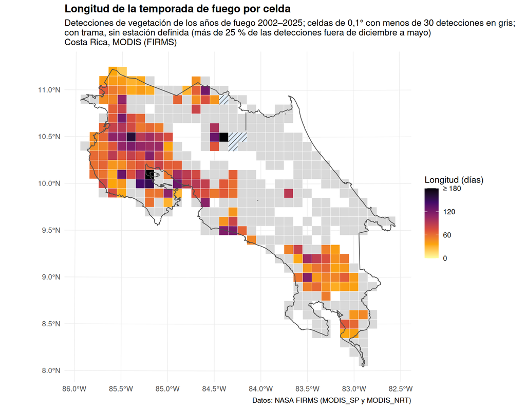

De las 406 celdas con alguna detección, 163 alcanzan el umbral y 4 de ellas quedan sin estación definida, con entre 27 y 58 % de sus detecciones fuera de diciembre a mayo (en las demás la mediana es 0 %). En las 159 celdas con índices la temporada consolidada dura entre 20 y 212 días (mediana 64). El inicio más temprano de celda cae el 12 de octubre y el más tardío el 11 de abril; el fin, entre el 18 de marzo y el 6 de agosto. En el mapa de longitud la escala de color se acota en 180 días; el valor completo está en el ráster y en la tabla.

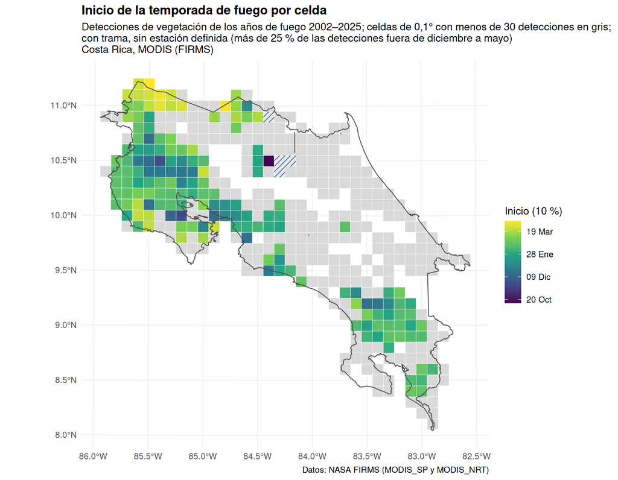

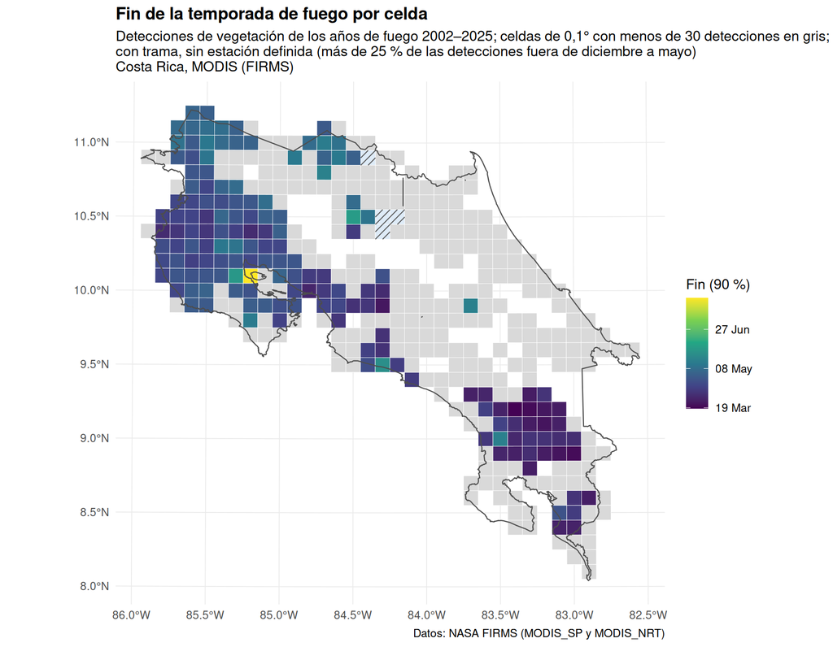

La grilla es común a las cuatro plataformas y a las variables climáticas que se incorporen después (celda base de 0,05° alineada a CHIRPS; celda de análisis de 0,1° centrada en los nodos de ERA5-Land), y el ráster se calcula por plataforma, nunca mezclando detecciones de sensores distintos. Los índices por celda están disponibles como CSV y como GeoTIFF con una capa por índice, incluida `FUERA`; las mismas celdas pueden activarse como capa del mapa interactivo.

### Detecciones excluidas por tipo de fuente

FIRMS clasifica cada detección del procesamiento estándar por tipo de fuente: vegetación, volcán activo (Turrialba, Poás, Rincón de la Vieja), otra fuente estática en tierra (típicamente industrial) o mar. En el registro MODIS hay **1 428** detecciones de los tres últimos tipos, que las series mensuales y los mapas de este reporte sí incluyen (son anomalías térmicas en sentido amplio) pero los índices de temporada apartan. La cola en tiempo casi real no trae el campo, de modo que sus detecciones (*sin tipo*) cuentan como vegetación y en el año provisional pueden colarse fuentes que el procesamiento estándar sí etiquetaría.

| Año de fuego | Vegetación | Sin tipo (NRT) | Volcán activo | Otra fuente estática | Mar | Excluidas |
| --- | --- | --- | --- | --- | --- | --- |
| 2001 | 775 | 0 | 16 | 3 | 2 | 21 |
| 2002 | 599 | 0 | 15 | 6 | 2 | 23 |
| 2003 | 1657 | 0 | 65 | 12 | 2 | 79 |
| 2004 | 1399 | 0 | 41 | 16 | 1 | 58 |
| 2005 | 1008 | 0 | 63 | 29 | 2 | 94 |
| 2006 | 884 | 0 | 56 | 21 | 1 | 78 |
| 2007 | 1074 | 0 | 53 | 32 | 2 | 87 |
| 2008 | 782 | 0 | 46 | 27 | 1 | 74 |
| 2009 | 955 | 0 | 38 | 20 | 5 | 63 |
| 2010 | 989 | 0 | 22 | 24 | 2 | 48 |

[output cut: 16 more lines]

Disponible también como CSV.

## Detecciones por área de conservación

A escala nacional interesa no solo cuándo ocurre el fuego sino dónde. La unidad de desagregación es el **área de conservación**: la división con que el [SINAC](https://www.sinac.go.cr/) administra el territorio (y gestiona el fuego). Cada detección se asigna al área de conservación donde cae su punto; cada píxel de área quemada, a la del centroide del píxel. Las pocas detecciones que no caen en ninguna —desajustes de borde entre la capa del SINAC y el límite IGN 1:5000, típicamente en la línea de costa— se agrupan como *Sin asignar*.

[interactive chart not shown]

| Siglas | Área de conservación | Detecciones | % del total | Hectáreas quemadas |
| --- | --- | --- | --- | --- |
| ACT | Tempisque | 7429 | 25.2 | 264953 |
| ACAT | Arenal Tempisque | 6068 | 20.6 | 222708 |
| ACG | Guanacaste | 5770 | 19.5 | 270901 |
| ACLAP | La Amistad Pacifico | 3041 | 10.3 | 36662 |
| ACOPAC | Pacifico Central | 2396 | 8.1 | 38375 |
| ACAHN | Huetar Norte | 2030 | 6.9 | 29205 |
| ACC | Central | 1249 | 4.2 | 3613 |
| ACOSA | Osa | 1022 | 3.5 | 2971 |
| ACLAC | La Amistad Caribe | 349 | 1.2 | 406 |
| ACTo | Tortuguero | 146 | 0.5 | 257 |

[output cut: 1 more lines]

La distribución por año y área de conservación está disponible como CSV.

## Cobertura de la tierra

Cada detección MODIS corresponde a un píxel de ~1 km (mayor fuera del nadir), por lo que la cobertura se caracteriza sobre el *footprint* completo de la detección (una elipse con las dimensiones reales del píxel, columnas `scan` × `track`) y no sobre el punto exacto. El gráfico muestra cuántas detecciones tienen cada clase de [ESA WorldCover 2021](https://esa-worldcover.org/) (10 m) como cobertura dominante de su footprint.

**Limitación**: WorldCover describe la cobertura de 2021, mientras que el registro de detecciones abarca 2001–2026; los cambios de cobertura en ese período no están representados.

El contraste con la composición del paisaje es informativo: según WorldCover el país es **75,1 %** bosque y **20,2 %** pastizal, pero solo el **57,4 %** de las detecciones tiene bosque como clase dominante de su footprint, frente al **25,6 %** con pastizal. El fuego está sobrerrepresentado en la vegetación herbácea y los cultivos, y subrepresentado en el bosque.

Cada barra se divide además según la detección caiga o no dentro de un humedal del [Registro Nacional de Humedales](https://geos1pne.sirefor.go.cr/wfs) del SINAC (actualización 2016–2018 del Inventario Nacional de Humedales). El humedal no es un tipo de vegetación que compita con *pastizal* o *bosque*, sino una condición del sitio: las capas del SINAC inventarían rasgos específicos y no cubren todo el territorio, por lo que no pueden sustituir a WorldCover como clasificación exhaustiva, pero sí complementarla.

[interactive chart not shown]

El gráfico gemelo muestra las **hectáreas quemadas** según la clase dominante del píxel MCD64A1. Aquí la clase se asigna al píxel de 500 m completo —no a un footprint elíptico— y aplica la misma limitación de la foto fija de 2021.

[interactive chart not shown]

### Contraste con el Registro Nacional de Humedales

WorldCover es un producto global y clasifica como *pastizal* buena parte de la vegetación herbácea inundable del país (las marismas del Tempisque, los humedales del Caribe norte). El contraste con el registro de humedales permite distinguir cuánto del fuego “en pastizal” ocurre en realidad en humedales estacionales.

| Clase WorldCover | Detecciones | En humedal | % en humedal | Fracción del footprint en humedal | Hectáreas quemadas | % del área quemada en humedal |
| --- | --- | --- | --- | --- | --- | --- |
| Bosque | 16953 | 1280 | 7.6 | 0.014 | 316199 | 4.5 |
| Pastizal | 7562 | 1328 | 17.6 | 0.075 | 238550 | 14.3 |
| Cultivos | 3949 | 469 | 11.9 | 0.038 | 314019 | 3.2 |
| Zonas construidas | 915 | 16 | 1.7 | 0 | 192 | 0 |
| Manglar | 71 | 48 | 67.6 | 0.273 | 1561 | 72.6 |
| Cuerpos de agua | 33 | 12 | 36.4 | 0.192 | 1753 | 35.4 |
| Humedal herbáceo | 28 | 28 | 100 | 0.65 | 684 | 87.5 |
| Suelo desnudo / vegetación escasa | 9 | 0 | 0 | 0 | 107 | 100 |
| Matorral | 0 | 0 |  |  | 64 | 0 |

Las dos últimas columnas extienden el contraste al área quemada: hectáreas por clase dominante del píxel y qué porcentaje de esas hectáreas cae dentro de un humedal registrado.

De las **7 562** detecciones cuyo footprint domina el *pastizal* de WorldCover, el **17,6 %** cae dentro de un humedal registrado (con un **8 %** del footprint cubierto por humedal, en promedio). El polígono del registro que más detecciones concentra es *Sector Catalina 1*, con 160.

**Advertencia sobre la clase de humedal**: el registro asigna una sola clase por polígono. La columna `clase_hum` describe el tipo de humedal *como sitio* y no la cobertura en cada punto de su extensión, de modo que el cruce es concluyente para responder si las detecciones ocurren en humedal, pero no para determinar qué tipo de vegetación se quemó; para eso siguen siendo preferibles los productos con detalle espacial fino.

## El episodio del humedal Catalina, mayo de 2026

Casi todo lo que este reporte mide carece de contraparte en tierra: nadie levantó un inventario de las quemas de 2004 para comparar. El episodio de mayo de 2026 en el humedal Catalina (Parque Nacional Palo Verde, cuenca baja del Tempisque) es la excepción, y por eso merece una sección propia. El 28 de mayo de 2026 la caída de un rayo encendió el interior del humedal, y una semana después Delfino.cr reportaba, con cifras del Minae-Sinac, que el fuego había afectado **cerca de 4 000 hectáreas** ([nota del 3 de junio de 2026](https://delfino.cr/2026/06/incendio-en-parque-nacional-palo-verde-afecto-cerca-de-4000-hectareas)). El combustible principal fue la *Typha*, una planta invasora que arde incluso sobre el agua. Hay entonces una fecha de ignición, una causa y una superficie oficial: tres cosas con las que auditar los productos satelitales.

**Lo que vio esta plataforma.** MODIS registró **11 detecciones** en la ventana del evento, en 3 días, del 30 de mayo al 1 de junio de 2026 —el fuego apareció en las imágenes 2 días después de la ignición reportada—, con una potencia radiativa acumulada de 307 MW y un máximo de 50,3 MW en un solo píxel.

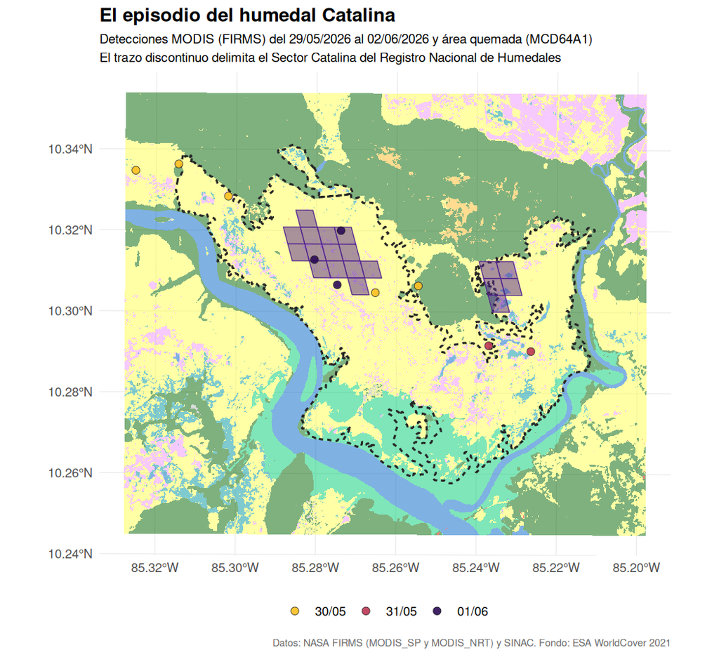

Esas 11 detecciones son el dato más elocuente de esta sección, pero por lo que **no** dicen. Los tres reportes VIIRS registran entre 102 y 176 detecciones del mismo incendio, en los mismos días y sobre el mismo humedal: entre **9 y 16 veces más** que MODIS. La diferencia no está en el fuego sino en el instrumento. El píxel de ~1 km promedia la radiancia sobre una superficie siete veces mayor que el de 375 m, de modo que un frente de llama que ocupa una fracción del píxel eleva su temperatura aparente lo justo para pasar desapercibido. **Un incendio de miles de hectáreas puede reducirse a un puñado de píxeles en MODIS**, y ese es el argumento más concreto a favor de mantener las cuatro plataformas en paralelo en lugar de confiar en la serie más larga.

**Dónde ardió.** El **72,7 %** de las detecciones del episodio tiene como polígono dominante el *Sector Catalina* del Registro Nacional de Humedales, y el **90,9 %** cae en footprints donde WorldCover ve *pastizal*. Es un ejemplo concreto del hallazgo de la sección anterior: parte del “pastizal” que arde en Costa Rica no es potrero sino humedal estacional, y esta vez sabemos por la fuente periodística que lo que ardió fue un typhal sobre agua.

**Lo que el área quemada no vio.** Para mayo y junio de 2026, MCD64A1 marca **2095 hectáreas** quemadas en la zona del evento, frente a las 4 000 reportadas oficialmente. Con la cicatriz completa —MCD64A1 ya publicó todos los meses del evento— la brecha es de **1,9 veces**; el reporte de Suomi-NPP, con VNP64A1, la sitúa en 1,2 veces.

La explicación está en cómo funciona el producto. MCD64A1 declara quemado un píxel de 500 m cuando detecta un **cambio persistente de reflectancia**, y una quema de *Typha* sobre lámina de agua no lo produce: la vegetación emergente desaparece, el agua vuelve a dominar la señal y a las pocas semanas la superficie se parece a lo que era antes. A eso se suma que el píxel de 500 m no resuelve las cicatrices delgadas e interrumpidas que deja un fuego que avanza entre canales. No es un defecto de este episodio sino el comportamiento esperable del algoritmo en humedales, y advierte contra leer las hectáreas de la tabla anual como una medida de la superficie realmente afectada: **sirven para comparar años entre sí, no para responder cuántas hectáreas se quemaron.**

## Fuentes de datos

- **NASA FIRMS** — Fire Information for Resource Management System, producto MODIS_SP (MODIS Collection 6.1, procesamiento estándar). https://firms.modaps.eosdis.nasa.gov/. Cita sugerida: NASA FIRMS, *MODIS Collection 6.1 Active Fire Detections*, DOI: 10.5067/FIRMS/MODIS/MCD14ML.
- **NASA LP DAAC** — producto de área quemada MCD64A1 v6.1 (MODIS Terra+Aqua, mensual, 500 m), descubierto vía el API CMR de Earthdata. Giglio, L., et al. (2021). *MCD64A1 MODIS/Terra+Aqua Burned Area Monthly L3 Global 500m SIN Grid V061*, DOI: 10.5067/MODIS/MCD64A1.061.
- **IGN / SNIT** — Instituto Geográfico Nacional, cartografía oficial 1:5000: límite provincial (la unión de las siete provincias es el límite nacional del análisis), descargado del Sistema Nacional de Información Territorial. https://www.snitcr.go.cr/.
- **SINAC** — Sistema Nacional de Áreas de Conservación de Costa Rica. Capas de áreas de conservación y Registro Nacional de Humedales (actualización 2016–2018), descargadas de su servicio WFS. https://geos1pne.sirefor.go.cr/wfs.
- **ESA WorldCover** — mapa global de cobertura de la tierra 2021 a 10 m, v200. https://esa-worldcover.org/. Zanaga, D., et al. (2022). *ESA WorldCover 10 m 2021 v200*, DOI: 10.5281/zenodo.7254221.

El código de este análisis está disponible en https://github.com/incendios-forestales/anomalias-termicas-costarica.